# Project 3

Van Nguyen

2024-12-11

## The Dataset: Heart Failure Clinical Records

The data set is a record of patients who had heart failure. Using the age of the patient, whether or not they have high blood pressure, checking their serum creatinine and serum sodium level, and ejection fraction percentage, we will try to predict whether the patient will pass away in the follow up period.

## Summaries

```r
heartfail1 <- heartfail[,c("age","high_blood_pressure","ejection_fraction","serum_creatinine","serum_sodium","DEATH_EVENT")]
attach(heartfail1)
summary(heartfail1)
```

```
##       age        high_blood_pressure ejection_fraction serum_creatinine
##  Min.   :40.00   Min.   :0.0000      Min.   :14.00     Min.   :0.500
##  1st Qu.:51.00   1st Qu.:0.0000      1st Qu.:30.00     1st Qu.:0.900
##  Median :60.00   Median :0.0000      Median :38.00     Median :1.100
##  Mean   :60.83   Mean   :0.3512      Mean   :38.08     Mean   :1.394
##  3rd Qu.:70.00   3rd Qu.:1.0000      3rd Qu.:45.00     3rd Qu.:1.400
##  Max.   :95.00   Max.   :1.0000      Max.   :80.00     Max.   :9.400
##   serum_sodium    DEATH_EVENT
##  Min.   :113.0   Min.   :0.0000
##  1st Qu.:134.0   1st Qu.:0.0000
##  Median :137.0   Median :0.0000
##  Mean   :136.6   Mean   :0.3211
##  3rd Qu.:140.0   3rd Qu.:1.0000
##  Max.   :148.0   Max.   :1.0000
```

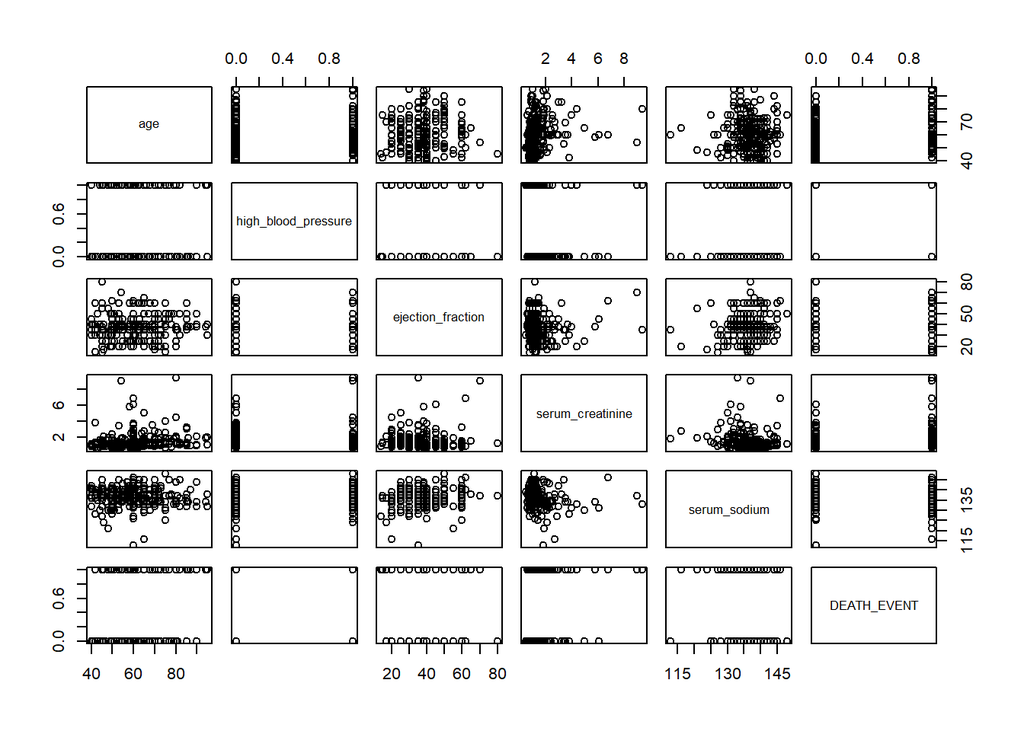

```r
plot(heartfail1)
```

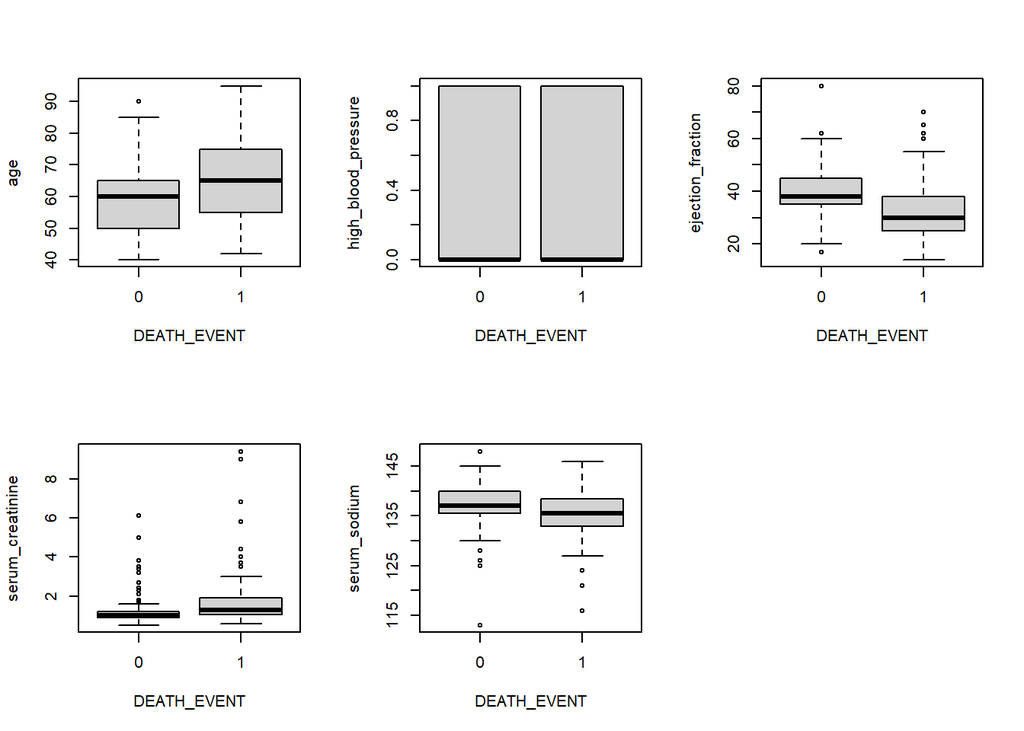

```r
par(mfrow=c(2,3))
boxplot(age ~ DEATH_EVENT)
boxplot(high_blood_pressure ~ DEATH_EVENT)
boxplot(ejection_fraction ~ DEATH_EVENT)
boxplot(serum_creatinine ~ DEATH_EVENT)
boxplot(serum_sodium ~ DEATH_EVENT)
```

The 0 and 1 for each boxplot looks kind of close with each other with the differentiating factor between them is one having longer whiskers than the other. It feels hard to determined the usefulness of a variable based on the graphs.

## Logistic Regression Models

```r
# Creation of Training and Test Data Set
set.seed(0) #So the data set remains the same after I knit it
train_sample <- sample(c(TRUE, FALSE), size = nrow(heartfail1), replace = TRUE, prob = c(0.5,0.5))
train <- heartfail1[train_sample,]
test <- heartfail1[!train_sample,]
```

```r
# First model
mod1 <- glm(DEATH_EVENT ~ ., data=train, family="binomial")
summary(mod1)
```

```
##
## Call:
## glm(formula = DEATH_EVENT ~ ., family = "binomial", data = train)
##
## Coefficients:
##                     Estimate Std. Error z value Pr(>|z|)
## (Intercept)          6.30476    6.76286   0.932  0.35120
## age                  0.04854    0.01794   2.706  0.00680 **
## high_blood_pressure  0.42930    0.41692   1.030  0.30315
## ejection_fraction   -0.05328    0.01866  -2.856  0.00430 **
## serum_creatinine     0.66656    0.21785   3.060  0.00222 **
## serum_sodium        -0.06666    0.04952  -1.346  0.17827
## ---
## Signif. codes:  0 '***' 0.001 '**' 0.01 '*' 0.05 '.' 0.1 ' ' 1
##
## (Dispersion parameter for binomial family taken to be 1)
##
##     Null deviance: 181.29  on 139  degrees of freedom
## Residual deviance: 146.10  on 134  degrees of freedom
## AIC: 158.1
##
## Number of Fisher Scoring iterations: 5
```

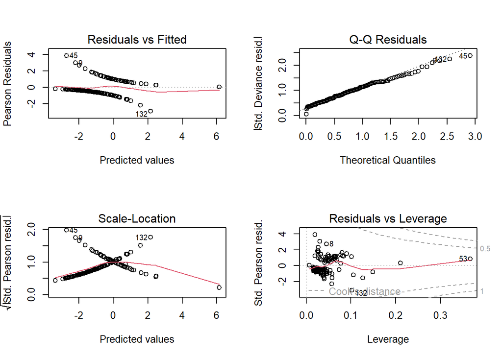

```r
par(mfrow=c(2,2))
plot(mod1)
```

```r
# Second model
train1 <- train[-63,]
mod2 <- glm(DEATH_EVENT ~ ., data=train1, family="binomial")
summary(mod2)
```

```
##
## Call:
## glm(formula = DEATH_EVENT ~ ., family = "binomial", data = train1)
##
## Coefficients:
##                     Estimate Std. Error z value Pr(>|z|)
## (Intercept)          7.48952    7.12167   1.052  0.29296
## age                  0.04663    0.01832   2.546  0.01089 *
## high_blood_pressure  0.41470    0.42604   0.973  0.33037
## ejection_fraction   -0.05122    0.01900  -2.696  0.00702 **
## serum_creatinine     0.95016    0.30799   3.085  0.00204 **
## serum_sodium        -0.07756    0.05194  -1.493  0.13534
## ---
## Signif. codes:  0 '***' 0.001 '**' 0.01 '*' 0.05 '.' 0.1 ' ' 1
##
## (Dispersion parameter for binomial family taken to be 1)
##
##     Null deviance: 180.42  on 138  degrees of freedom
## Residual deviance: 140.39  on 133  degrees of freedom
## AIC: 152.39
##
## Number of Fisher Scoring iterations: 5
```

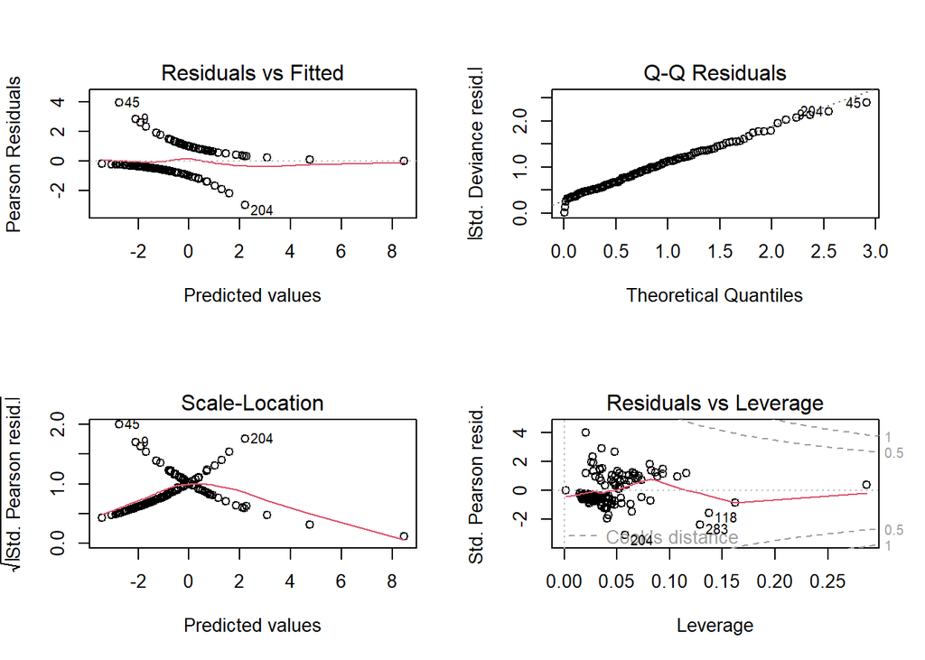

```r
par(mfrow=c(2,2))
plot(mod2)
```

There is a lower AIC so the model is better with the removal of row #132.

```r
# Third model/ Final Model
mod3 <- glm(DEATH_EVENT ~ .-high_blood_pressure, data=train1, family="binomial")
summary(mod3)
```

```
##
## Call:
## glm(formula = DEATH_EVENT ~ . - high_blood_pressure, family = "binomial",
##     data = train1)
##
## Coefficients:
##                   Estimate Std. Error z value Pr(>|z|)
## (Intercept)        7.48430    7.19677   1.040  0.29836
## age                0.04615    0.01820   2.535  0.01123 *
## ejection_fraction -0.05115    0.01894  -2.701  0.00692 **
## serum_creatinine   0.92648    0.30467   3.041  0.00236 **
## serum_sodium      -0.07589    0.05226  -1.452  0.14646
## ---
## Signif. codes:  0 '***' 0.001 '**' 0.01 '*' 0.05 '.' 0.1 ' ' 1
##
## (Dispersion parameter for binomial family taken to be 1)
##
##     Null deviance: 180.42  on 138  degrees of freedom
## Residual deviance: 141.34  on 134  degrees of freedom
## AIC: 151.34
##
## Number of Fisher Scoring iterations: 5
```

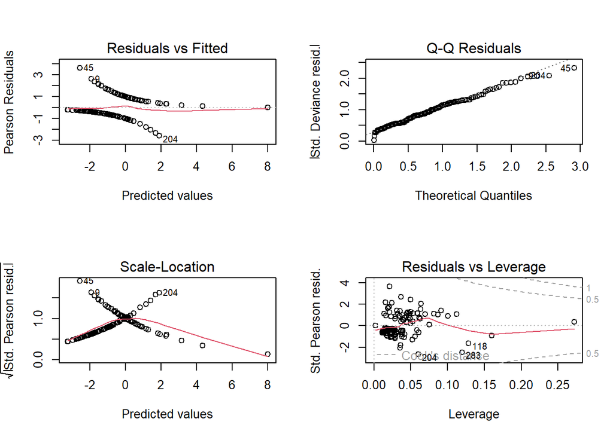

```r
par(mfrow=c(2,2))
plot(mod3)
```

Lower AIC compared to previous model with the removal of high blood pressure.

```r
# Fourth Model
mod4 <- glm(DEATH_EVENT ~ .-high_blood_pressure -serum_sodium, data=train1, family="binomial")
summary(mod4)
```

```
##
## Call:
## glm(formula = DEATH_EVENT ~ . - high_blood_pressure - serum_sodium,
##     family = "binomial", data = train1)
##
## Coefficients:
##                   Estimate Std. Error z value Pr(>|z|)
## (Intercept)       -2.83738    1.23166  -2.304  0.02124 *
## age                0.04803    0.01803   2.663  0.00774 **
## ejection_fraction -0.05694    0.01880  -3.029  0.00245 **
## serum_creatinine   0.98307    0.31988   3.073  0.00212 **
## ---
## Signif. codes:  0 '***' 0.001 '**' 0.01 '*' 0.05 '.' 0.1 ' ' 1
##
## (Dispersion parameter for binomial family taken to be 1)
##
##     Null deviance: 180.42  on 138  degrees of freedom
## Residual deviance: 143.51  on 135  degrees of freedom
## AIC: 151.51
##
## Number of Fisher Scoring iterations: 5
```

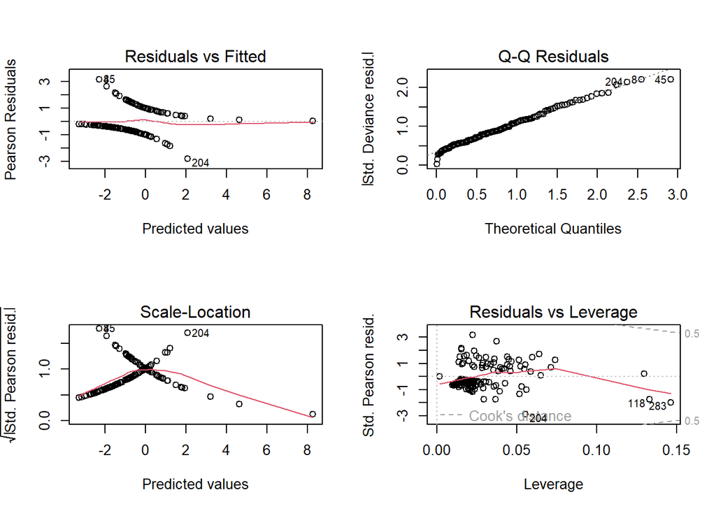

```r
par(mfrow=c(2,2))
plot(mod4)
```

There was an increase in the AIC so serum sodium is kind of significant and important to the model. Mostly likely with another variable that was not chosen, its p-value could be lowered to a significant level. So the final model will be the third model.

# Prediction

```r
library(pROC)
```

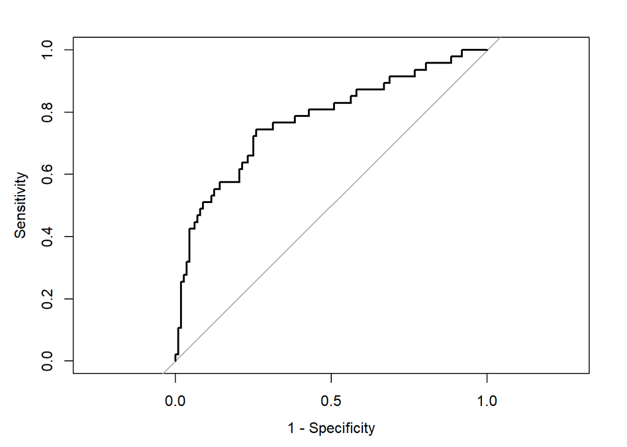

```r
# ROC Curve
prob <- predict(mod3, test, type="response")
curve <- roc(test$DEATH_EVENT, prob, plot=TRUE,legacy.axes=TRUE)
```

```r
# Optimal Cutoff Value, Specificity, Sensitivity
coords(curve, "best") #
```

```
##   threshold specificity sensitivity
## 1 0.3241706   0.7410714   0.7446809
```

```r
# Confusion Matrix
prediction <- rep(0, length(prob))
prediction[prob > coords(curve, "best")[1,1]] <- 1
tab <- table(prediction, test$DEATH_EVENT)
tab
```

```
##
## prediction  0  1
##          0 83 12
##          1 29 35
```

```r
# Misclassification rate
(tab[1,2] + tab[2,1]) / nrow(test)
```

```
## [1] 0.2578616
```

## Conclusions

As of now the final model is okay at predicting whether the patient will pass away during the follow up period after a heart failure. With a 74% in both specificity and sensitivity, the model is good at predicting both if a patient will pass away and will survive. However, it it ideal to decrease the 25% misclassification rate since the misclassification 1 in 4 people is too much when the life of a person is in play. Future models should test the other variables to further increase the specificity and sensitivity and decrease the misclassification rate.

Interestingly, the fourth model (mod4) has a higher specificity and lower misclassification rate at the cost of a lower sensitivity.

```r
# ROC Curve
prob <- predict(mod4, test, type="response")
curve <- roc(test$DEATH_EVENT, prob)
# Optimal Cutoff Value, Specificity, Sensitivity
coords(curve, "best") #
```

```
##   threshold specificity sensitivity
## 1 0.3664196   0.8035714   0.7234043
```

```r
# Confusion Matrix
prediction <- rep(0, length(prob))
prediction[prob > coords(curve, "best")[1,1]] <- 1
tab <- table(prediction, test$DEATH_EVENT)
tab
```

```
##
## prediction  0  1
##          0 90 13
##          1 22 34
```

```r
# Misclassification rate
(tab[1,2] + tab[2,1]) / nrow(test)
```

```
## [1] 0.2201258
```